# users & trips for Bikes

## Investigation Overview

In this investigation, I wanted to look at the characteristics of bike trips duration ,timing and users that could be used to predict the most important days to maintaine the bikes .

## What is the users Age?

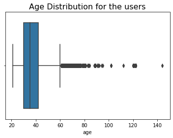

so the younger user is 20 yars old and the older is 144 year ,wow the average age of the users is 37 years old.

### How Many trip for each day?

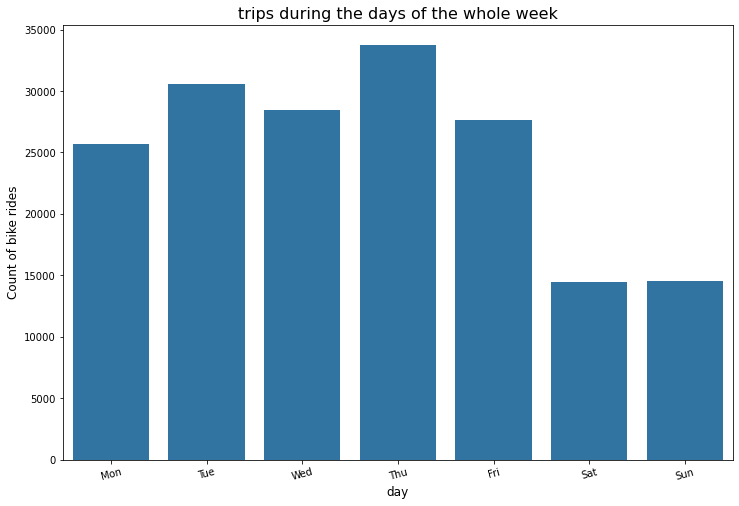

### the less trips are in the weekend.

### what is the rush hour in using bikes ??

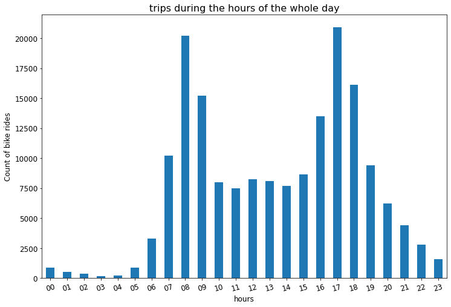

### The normal Rush Hours at 8 am & 5 pm.

### what is the most important stations ??

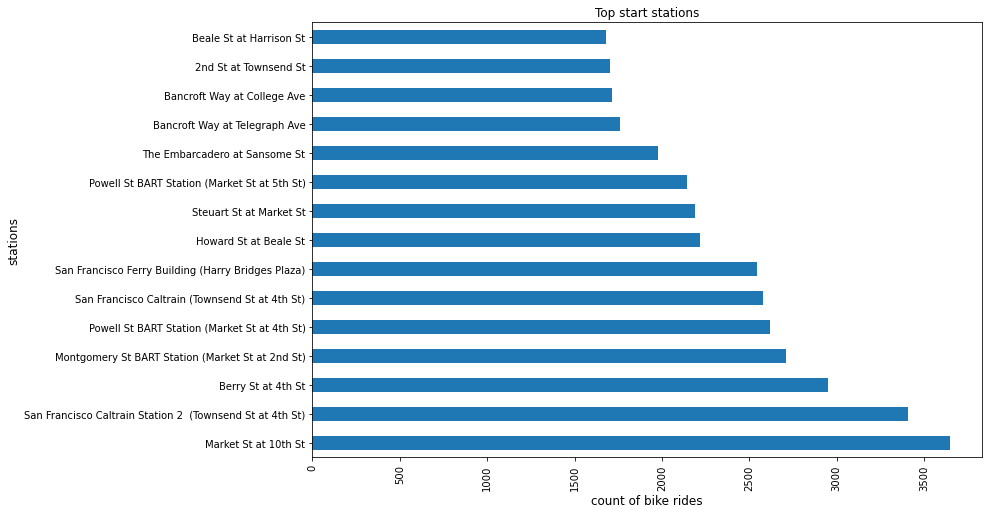

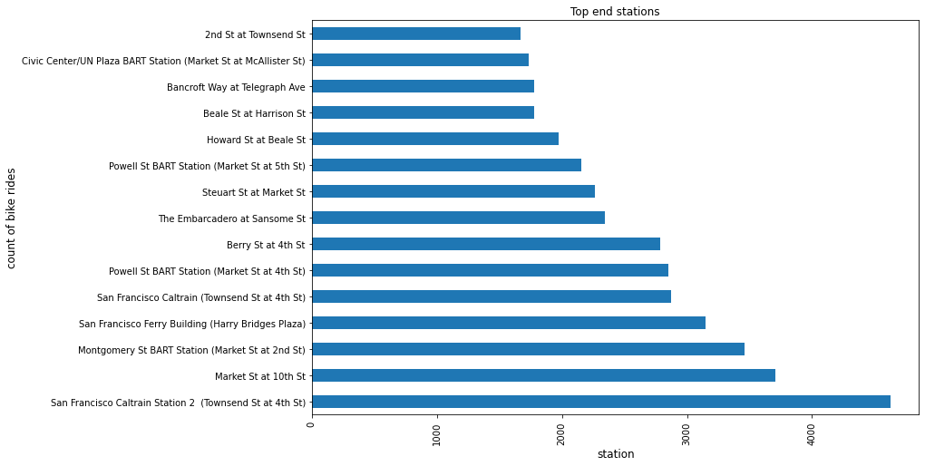

it is thursday the most crowded day in the normal rush hours , the most used station is san francisco cattrain station 2& market st 10 , it is the most importat station to care with )